# Ecommerce

# High value customers identification for an E-Commerce company

## DESCRIPTION

### Background of Problem Statement:

#### A UK-based online retail store has captured the sales data for different products for the period of one year (Nov 2016 to Dec 2017). The organization #### sells gifts primarily on the online platform. The customers who make a purchase consume directly for themselves. There are small businesses that buy in #### bulk and sell to other customers through the retail outlet channel.

## Project Objective:

#### Find significant customers for the business who make high purchases of their favourite products. The organization wants to roll out a loyalty program to #### the high-value customers after identification of segments. Use the clustering methodology to segment customers into groups:

## Domain: E-commerce

## ataset Description:

### This is a transnational dataset that contains all the transactions occurring between Nov-2016 to Dec-2017 for a UK-based online retail store.

### InvoiceNo Invoice number (A 6-digit integral number uniquely assigned to each transaction)

### StockCode Product (item) code

### Description Product (item) name

### Quantity The quantities of each product (item) per transaction

### InvoiceDate The day when each transaction was generated

### UnitPrice Unit price (Product price per unit)

### CustomerID Customer number (Unique ID assigned to each customer)

### Country Country name (The name of the country where each customer resides)

## Clearning the Environment

```r
rm(list = ls(all = TRUE))
```

## Reading the Ecommerce csv file

```r
Ecom <- read.csv('Ecommerce.csv',header = TRUE, na.strings = c("NA","","?"," "))
```

# Exploratory Data Analysis

### Printing head and tail of the dataset

```r
head(Ecom)
```

```
##   InvoiceNo StockCode                         Description Quantity
## 1    536365    85123A  WHITE HANGING HEART T-LIGHT HOLDER        6
## 2    536365     71053                 WHITE METAL LANTERN        6
## 3    536365    84406B      CREAM CUPID HEARTS COAT HANGER        8
## 4    536365    84029G KNITTED UNION FLAG HOT WATER BOTTLE        6
## 5    536365    84029E      RED WOOLLY HOTTIE WHITE HEART.        6
## 6    536365     22752        SET 7 BABUSHKA NESTING BOXES        2
##   InvoiceDate UnitPrice CustomerID        Country  X
## 1   29-Nov-16      2.55      17850 United Kingdom NA
## 2   29-Nov-16      3.39      17850 United Kingdom NA
## 3   29-Nov-16      2.75      17850 United Kingdom NA
## 4   29-Nov-16      3.39      17850 United Kingdom NA
## 5   29-Nov-16      3.39      17850 United Kingdom NA
## 6   29-Nov-16      7.65      17850 United Kingdom NA
```

```r
tail(Ecom)
```

```
##        InvoiceNo StockCode                     Description Quantity
## 541904    581587     23256     CHILDRENS CUTLERY SPACEBOY         4
## 541905    581587     22613     PACK OF 20 SPACEBOY NAPKINS       12
## 541906    581587     22899    CHILDREN'S APRON DOLLY GIRL         6
## 541907    581587     23254   CHILDRENS CUTLERY DOLLY GIRL         4
## 541908    581587     23255 CHILDRENS CUTLERY CIRCUS PARADE        4
## 541909    581587     22138   BAKING SET 9 PIECE RETROSPOT         3
##        InvoiceDate UnitPrice CustomerID Country  X
## 541904    7-Dec-17      4.15      12680  France NA
## 541905    7-Dec-17      0.85      12680  France NA
## 541906    7-Dec-17      2.10      12680  France NA
## 541907    7-Dec-17      4.15      12680  France NA
## 541908    7-Dec-17      4.15      12680  France NA
## 541909    7-Dec-17      4.95      12680  France NA
```

### Getting the dimensions, column names, data structure and summary of the data

```r
dim(Ecom)
```

```
## [1] 541909      9
```

```r
colnames(Ecom)
```

```
## [1] "InvoiceNo"   "StockCode"   "Description" "Quantity"    "InvoiceDate"
## [6] "UnitPrice"   "CustomerID"  "Country"     "X"
```

```r
str(Ecom)
```

```
## 'data.frame':    541909 obs. of  9 variables:
##  $ InvoiceNo  : Factor w/ 25900 levels "536365","536366",..: 1 1 1 1 1 1 1 2 2 3 ...
##  $ StockCode  : Factor w/ 4070 levels "10002","10080",..: 3538 2795 3045 2986 2985 1663 801 1548 1547 3306 ...
##  $ Description: Factor w/ 4222 levels " 4 PURPLE FLOCK DINNER CANDLES",..: 4025 4033 930 1957 2978 3233 1571 1696 1693 257 ...
##  $ Quantity   : int  6 6 8 6 6 2 6 6 6 32 ...
##  $ InvoiceDate: Factor w/ 305 levels "1-Apr-17","1-Aug-17",..: 212 212 212 212 212 212 212 212 212 212 ...
##  $ UnitPrice  : num  2.55 3.39 2.75 3.39 3.39 7.65 4.25 1.85 1.85 1.69 ...
##  $ CustomerID : int  17850 17850 17850 17850 17850 17850 17850 17850 17850 13047 ...
##  $ Country    : Factor w/ 38 levels "Australia","Austria",..: 36 36 36 36 36 36 36 36 36 36 ...
##  $ X          : logi  NA NA NA NA NA NA ...
```

```r
summary(Ecom)
```

```
##    InvoiceNo        StockCode
##  573585 :  1114   85123A :  2313
##  581219 :   749   22423  :  2203
##  581492 :   731   85099B :  2159
##  580729 :   721   47566  :  1727
##  558475 :   705   20725  :  1639
##  579777 :   687   84879  :  1502
##  (Other):537202   (Other):530366
##                              Description        Quantity
##  WHITE HANGING HEART T-LIGHT HOLDER:  2369   Min.   :-80995.00
##  REGENCY CAKESTAND 3 TIER          :  2200   1st Qu.:     1.00
##  JUMBO BAG RED RETROSPOT           :  2159   Median :     3.00
##  PARTY BUNTING                     :  1727   Mean   :     9.55
##  LUNCH BAG RED RETROSPOT           :  1638   3rd Qu.:    10.00
##  (Other)                           :530315   Max.   : 80995.00
##  NA's                              :  1501
##     InvoiceDate       UnitPrice           CustomerID
##  3-Dec-17 :  5331   Min.   :-11062.06   Min.   :12346
##  6-Dec-17 :  4940   1st Qu.:     1.25   1st Qu.:13953
##  27-Nov-17:  4313   Median :     2.08   Median :15152
##  14-Nov-17:  4195   Mean   :     4.61   Mean   :15288
##  9-Nov-17 :  4089   3rd Qu.:     4.13   3rd Qu.:16791
##  6-Nov-17 :  4070   Max.   : 38970.00   Max.   :18287
##  (Other)  :514971                       NA's   :135080
##            Country          X
##  United Kingdom:495478   Mode:logical
##  Germany       :  9495   NA's:541909
##  France        :  8557
##  EIRE          :  8196
##  Spain         :  2533
##  Netherlands   :  2371
##  (Other)       : 15279
```

```r
Ecom$X <- NULL
```

```r
Ecom$InvoiceDate <- as.Date(Ecom$InvoiceDate,format="%d-%b-%y")
```

## Getting the duplicate rows form the dataset

```r
duplicate_rows <- data.frame(which(duplicated(Ecom)))
dim(duplicate_rows)
```

```
## [1] 5269    1
```

## Using only the unique rows for the analysis and then checking the dimension of the data

```r
Ecom <- unique(Ecom)
dim(Ecom)
```

```
## [1] 536640      8
```

### Getting the null values for the respective columns

```r
# new_DF <- Ecom[is.na(c(Ecom$Description, Ecom$CustomerID)),]
# sum(is.na(Ecom$CustomerID))
# new_DF
```

## Checking for Null values and then removing all the Null Values for the data set

### Checking the dimension of the dataset after elimintating the Null values from the data

```r
sum(is.na(Ecom))
```

```
## [1] 136538
```

```r
Ecom <- na.omit(Ecom)
sum(is.na(Ecom))
```

```
## [1] 0
```

```r
dim(Ecom)
```

```
## [1] 401603      8
```

### checking the structure of the dataset

```r
str(Ecom)
```

```
## 'data.frame':    401603 obs. of  8 variables:
##  $ InvoiceNo  : Factor w/ 25900 levels "536365","536366",..: 1 1 1 1 1 1 1 2 2 3 ...
##  $ StockCode  : Factor w/ 4070 levels "10002","10080",..: 3538 2795 3045 2986 2985 1663 801 1548 1547 3306 ...
##  $ Description: Factor w/ 4222 levels " 4 PURPLE FLOCK DINNER CANDLES",..: 4025 4033 930 1957 2978 3233 1571 1696 1693 257 ...
##  $ Quantity   : int  6 6 8 6 6 2 6 6 6 32 ...
##  $ InvoiceDate: Date, format: "2016-11-29" "2016-11-29" ...
##  $ UnitPrice  : num  2.55 3.39 2.75 3.39 3.39 7.65 4.25 1.85 1.85 1.69 ...
##  $ CustomerID : int  17850 17850 17850 17850 17850 17850 17850 17850 17850 13047 ...
##  $ Country    : Factor w/ 38 levels "Australia","Austria",..: 36 36 36 36 36 36 36 36 36 36 ...
##  - attr(*, "na.action")=Class 'omit'  Named int [1:135037] 606 1408 1409 1410 1411 1412 1413 1414 1415 1416 ...
##   .. ..- attr(*, "names")= chr [1:135037] "623" "1444" "1445" "1446" ...
```

# Creating a new Variable Total Purchase

```r
Ecom$totalpurchase <- Ecom$Quantity*Ecom$UnitPrice
head(Ecom)
```

```
##   InvoiceNo StockCode                         Description Quantity
## 1    536365    85123A  WHITE HANGING HEART T-LIGHT HOLDER        6
## 2    536365     71053                 WHITE METAL LANTERN        6
## 3    536365    84406B      CREAM CUPID HEARTS COAT HANGER        8
## 4    536365    84029G KNITTED UNION FLAG HOT WATER BOTTLE        6
## 5    536365    84029E      RED WOOLLY HOTTIE WHITE HEART.        6
## 6    536365     22752        SET 7 BABUSHKA NESTING BOXES        2
##   InvoiceDate UnitPrice CustomerID        Country totalpurchase
## 1  2016-11-29      2.55      17850 United Kingdom         15.30
## 2  2016-11-29      3.39      17850 United Kingdom         20.34
## 3  2016-11-29      2.75      17850 United Kingdom         22.00
## 4  2016-11-29      3.39      17850 United Kingdom         20.34
## 5  2016-11-29      3.39      17850 United Kingdom         20.34
## 6  2016-11-29      7.65      17850 United Kingdom         15.30
```

```r
max(Ecom$InvoiceDate)
```

```
## [1] "2017-12-07"
```

# Creating a variable called days since

```r
Ecom$days_since <- as.numeric(difftime(time1 = "2017-12-08",time2 = Ecom$InvoiceDate,units = "days"))
Ecom$days_since <- floor(Ecom$days_since)
head(Ecom)
```

```
##   InvoiceNo StockCode                         Description Quantity
## 1    536365    85123A  WHITE HANGING HEART T-LIGHT HOLDER        6
## 2    536365     71053                 WHITE METAL LANTERN        6
## 3    536365    84406B      CREAM CUPID HEARTS COAT HANGER        8
## 4    536365    84029G KNITTED UNION FLAG HOT WATER BOTTLE        6
## 5    536365    84029E      RED WOOLLY HOTTIE WHITE HEART.        6
## 6    536365     22752        SET 7 BABUSHKA NESTING BOXES        2
##   InvoiceDate UnitPrice CustomerID        Country totalpurchase days_since
## 1  2016-11-29      2.55      17850 United Kingdom         15.30        373
## 2  2016-11-29      3.39      17850 United Kingdom         20.34        373
## 3  2016-11-29      2.75      17850 United Kingdom         22.00        373
## 4  2016-11-29      3.39      17850 United Kingdom         20.34        373
## 5  2016-11-29      3.39      17850 United Kingdom         20.34        373
## 6  2016-11-29      7.65      17850 United Kingdom         15.30        373
```

```r
Ecom$InvoiceNo <- NULL
Ecom$StockCode <- NULL
Ecom$Description <- NULL
```

```r
Ecom$CustomerID <- as.factor(Ecom$CustomerID)
str(Ecom)
```

```
## 'data.frame':    401603 obs. of  7 variables:
##  $ Quantity     : int  6 6 8 6 6 2 6 6 6 32 ...
##  $ InvoiceDate  : Date, format: "2016-11-29" "2016-11-29" ...
##  $ UnitPrice    : num  2.55 3.39 2.75 3.39 3.39 7.65 4.25 1.85 1.85 1.69 ...
##  $ CustomerID   : Factor w/ 4372 levels "12346","12347",..: 4049 4049 4049 4049 4049 4049 4049 4049 4049 541 ...
##  $ Country      : Factor w/ 38 levels "Australia","Austria",..: 36 36 36 36 36 36 36 36 36 36 ...
##  $ totalpurchase: num  15.3 20.3 22 20.3 20.3 ...
##  $ days_since   : num  373 373 373 373 373 373 373 373 373 373 ...
##  - attr(*, "na.action")=Class 'omit'  Named int [1:135037] 606 1408 1409 1410 1411 1412 1413 1414 1415 1416 ...
##   .. ..- attr(*, "names")= chr [1:135037] "623" "1444" "1445" "1446" ...
```

```r
sum(Ecom$totalpurchase)
```

```
## [1] 8278516
```

## For Customer Segmentation, RFM analysis plays a very important role by segmenting the customers to their respective class.

### These RFM metrics are important indicators of a customer’s behavior because frequency and monetary value affects a customer’s lifetime value, and recency affects retention, a measure of engagement.

## RFM stands for Recency, Frequency and Monetary

### Recency : the more recent the purchase, the more responsive the customer is to promotions.

### Frequency : the more frequently the customer buys, the more engaged and satisfied they are.

### Monetary Value :monetary value differentiates heavy spenders from low-value purchasers.

### Using library(SQLDF) for creating RFM Variables

```r
library(sqldf)
RFM <- sqldf(" SELECT CustomerID, MIN(days_since) AS 'Recency', COUNT(*) AS 'Frequency', SUM(totalpurchase) AS 'Monetary_Value', SUM(Quantity) AS 'Total_Quantity', SUM(UnitPrice) AS 'Total_UnitPrice' FROM Ecom GROUP BY 1 ")
```

#### Printing the first 6 rows after creating RFM variables

```r
head(RFM)
```

```
##   CustomerID Recency Frequency Monetary_Value Total_Quantity
## 1      12346     325         2           0.00              0
## 2      12347       2       182        4310.00           2458
## 3      12348      75        31        1797.24           2341
## 4      12349      18        73        1757.55            631
## 5      12350     310        17         334.40            197
## 6      12352      36        95        1545.41            470
##   Total_UnitPrice
## 1            2.08
## 2          481.21
## 3          178.71
## 4          605.10
## 5           65.30
## 6         2211.10
```

```r
str(RFM)
```

```
## 'data.frame':    4372 obs. of  6 variables:
##  $ CustomerID     : Factor w/ 4372 levels "12346","12347",..: 1 2 3 4 5 6 7 8 9 10 ...
##  $ Recency        : num  325 2 75 18 310 36 204 232 214 22 ...
##  $ Frequency      : int  2 182 31 73 17 95 4 58 13 59 ...
##  $ Monetary_Value : num  0 4310 1797 1758 334 ...
##  $ Total_Quantity : int  0 2458 2341 631 197 470 20 530 240 1591 ...
##  $ Total_UnitPrice: num  2.08 481.21 178.71 605.1 65.3 ...
```

### Getting the summary of the RFM for better understanding of these variables

```r
summary(RFM)
```

```
##    CustomerID      Recency         Frequency       Monetary_Value
##  12346  :   1   Min.   :  0.00   Min.   :   1.00   Min.   : -4287.6
##  12347  :   1   1st Qu.: 16.00   1st Qu.:  17.00   1st Qu.:   291.8
##  12348  :   1   Median : 50.00   Median :  41.00   Median :   644.1
##  12349  :   1   Mean   : 91.58   Mean   :  91.86   Mean   :  1893.5
##  12350  :   1   3rd Qu.:143.00   3rd Qu.:  99.25   3rd Qu.:  1608.3
##  12352  :   1   Max.   :373.00   Max.   :7812.00   Max.   :279489.0
##  (Other):4366
##  Total_Quantity     Total_UnitPrice
##  Min.   :  -303.0   Min.   :    0.00
##  1st Qu.:   151.8   1st Qu.:   52.73
##  Median :   364.0   Median :  128.93
##  Mean   :  1119.1   Mean   :  319.12
##  3rd Qu.:   956.2   3rd Qu.:  299.10
##  Max.   :196719.0   Max.   :41376.33
##
```

#### From the above summary we can understand that, some customers haven’t appeared to the store from a long time. The reason for this maybe the customers didn’t find their product or didn’t like the service provided by that firm,

#### There are few customers are very regular and are spending a good amount of money

#### Looking at the monetary value there are negative values, this means that some customers would have returned their product and have asked for refund

#### There are also customers who’s frequency is very low but till their monetary value is very high. In this case, the customer might have bought product who’s cost is high.

# Modeling

### Importing NbClust library

```r
library(NbClust)
```

### Creating a copy of the dataset

```r
rfm <- data.frame(RFM)
head(rfm)
```

```
##   CustomerID Recency Frequency Monetary_Value Total_Quantity
## 1      12346     325         2           0.00              0
## 2      12347       2       182        4310.00           2458
## 3      12348      75        31        1797.24           2341
## 4      12349      18        73        1757.55            631
## 5      12350     310        17         334.40            197
## 6      12352      36        95        1545.41            470
##   Total_UnitPrice
## 1            2.08
## 2          481.21
## 3          178.71
## 4          605.10
## 5           65.30
## 6         2211.10
```

## Removing variables that are not required for clustering

```r
rfm$Total_Quantity <- NULL
rfm$Total_UnitPrice <- NULL
head(rfm)
```

```
##   CustomerID Recency Frequency Monetary_Value
## 1      12346     325         2           0.00
## 2      12347       2       182        4310.00
## 3      12348      75        31        1797.24
## 4      12349      18        73        1757.55
## 5      12350     310        17         334.40
## 6      12352      36        95        1545.41
```

# 1.K-Means Clustering

### Setting Seed value

```r
set.seed(123)
```

### Here for K-means custering, i am using K = 3, becuase i want the customers to be segmented into three categories i.e. Low, Medium and High. As it make more sense when we group the customers into these three groups

### Scaling the data, here we have data of different scales. For clustering, the data should be in same scale

```r
kmc <- kmeans(scale(rfm[,2:4]),3, nstart = 1 )
kmc
```

```
## K-means clustering with 3 clusters of sizes 12, 3260, 1100
##
## Cluster means:
##      Recency   Frequency Monetary_Value
## 1 -0.8657935 11.87444916   14.195818754
## 2 -0.5151746  0.05125092    0.006519695
## 3  1.5362352 -0.28142853   -0.174185483
##
## Clustering vector:
##    [1] 3 2 2 2 3 2 3 3 3 2 2 2 2 2 3 2 2 2 3 2 2 2 2 3 2 2 3 2 2 2 2 3 2 3
##   [35] 2 2 2 2 2 2 2 2 2 3 3 2 3 2 2 2 2 3 2 2 3 1 2 2 2 2 2 2 3 2 3 2 2 2
##   [69] 2 2 2 2 2 2 2 2 2 3 2 2 2 2 3 2 2 3 2 2 2 2 2 2 2 2 2 2 2 2 2 3 2 2
##  [103] 2 2 2 2 2 2 2 2 2 2 2 2 3 2 2 2 3 2 2 2 2 3 2 3 2 3 3 2 2 3 3 2 2 3
##  [137] 3 2 2 2 2 2 3 2 2 2 2 2 2 2 2 2 2 2 2 2 2 2 2 2 2 2 3 3 2 3 2 2 2 2
##  [171] 2 3 2 3 2 3 3 2 2 2 2 2 3 3 2 2 2 2 3 2 3 2 2 3 2 2 2 2 3 3 2 2 2 2
```

[output cut: 133 more lines]

```r
kmc$totss
```

```
## [1] 13113
```

```r
kmc$withinss
```

```
## [1] 2364.4742 2502.9165  535.8895
```

```r
kmc$tot.withinss
```

```
## [1] 5403.28
```

```r
kmc$betweenss
```

```
## [1] 7709.72
```

### Adding the cluster variable to the actual data.

```r
rfm$cluster <- as.factor(kmc$cluster)
head(rfm)
```

```
##   CustomerID Recency Frequency Monetary_Value cluster
## 1      12346     325         2           0.00       3
## 2      12347       2       182        4310.00       2
## 3      12348      75        31        1797.24       2
## 4      12349      18        73        1757.55       2
## 5      12350     310        17         334.40       3
## 6      12352      36        95        1545.41       2
```

```r
dim(rfm)
```

```
## [1] 4372    5
```

```r
summary(rfm)
```

```
##    CustomerID      Recency         Frequency       Monetary_Value
##  12346  :   1   Min.   :  0.00   Min.   :   1.00   Min.   : -4287.6
##  12347  :   1   1st Qu.: 16.00   1st Qu.:  17.00   1st Qu.:   291.8
##  12348  :   1   Median : 50.00   Median :  41.00   Median :   644.1
##  12349  :   1   Mean   : 91.58   Mean   :  91.86   Mean   :  1893.5
##  12350  :   1   3rd Qu.:143.00   3rd Qu.:  99.25   3rd Qu.:  1608.3
##  12352  :   1   Max.   :373.00   Max.   :7812.00   Max.   :279489.0
##  (Other):4366
##  cluster
##  1:  12
##  2:3260
##  3:1100
##
##
##
##
```

### subsetting the data cluster wise and to understand the contributon made by each cluster group.

```r
library(dplyr)
K_Means_Results <- rfm %>%
  group_by(cluster) %>%
  summarise('Number of Customers' = n(),
            'AVG_Recency' = round(mean(Recency)),
            'AVG_Frequency' = scales::comma(round(mean(Frequency))),
            'AVG_Monetary_Value' = scales::dollar(round(mean(Monetary_Value))),
            'Revenue_Clusterwise' = scales::dollar(sum(Monetary_Value)))
```

#### Printing the results

```r
K_Means_Results
```

```
## # A tibble: 3 x 6
##   cluster `Number of Cust~ AVG_Recency AVG_Frequency AVG_Monetary_Va~
##   <fct>              <int>       <dbl> <chr>         <chr>
## 1 1                     12           4 2,814         $118,565
## 2 2                   3260          40 104           $1,947
## 3 3                   1100         246 27            $462
## # ... with 1 more variable: Revenue_Clusterwise <chr>
```

# 2.Hierarchical Clustering

## Dissimilarity matrix

```r
d <- dist(scale(rfm[,2:4]), method = 'euclidean')
```

```r
hc <- hclust(d, method = "ward.D" )
```

## Plot the obtained dendrogram

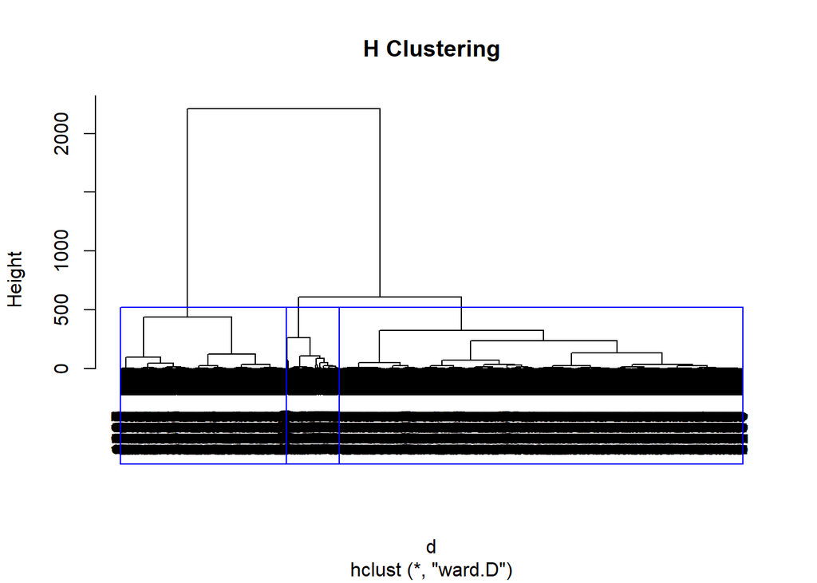

```r
plot(hc,main = 'H Clustering')
rect.hclust(hc, k = 3, border = 'blue')
```

### Using K= 3

```r
clusters <- cutree(hc, k = 3)
clusters
```

```
##    [1] 1 2 2 2 1 2 1 1 1 2 2 2 3 2 1 3 2 2 1 2 2 2 2 1 2 2 1 2 2 2 2 1 2 1
##   [35] 2 2 2 2 2 2 2 2 2 1 1 2 1 2 2 2 2 1 2 2 1 3 2 2 2 2 2 2 1 2 1 2 3 2
##   [69] 2 3 2 3 2 2 2 2 2 1 2 2 2 2 1 2 2 1 3 2 1 2 2 2 2 2 2 2 2 2 2 1 3 3
##  [103] 2 3 2 3 3 2 2 2 3 2 3 2 1 3 2 2 1 2 2 2 2 1 2 1 2 1 1 1 2 1 1 2 2 1
##  [137] 1 2 3 2 2 2 1 2 2 2 2 2 2 2 2 2 2 2 3 2 3 3 2 2 2 2 1 1 2 1 2 2 2 2
##  [171] 2 1 2 1 2 1 1 2 3 2 2 2 1 1 2 2 2 2 1 2 1 3 2 1 2 2 2 2 2 1 2 2 2 2
##  [205] 3 2 2 2 1 2 2 2 1 2 2 2 2 2 2 1 2 2 2 2 2 2 3 1 1 2 1 3 3 2 2 2 2 2
##  [239] 3 2 1 2 2 2 2 1 2 2 2 1 2 2 1 1 1 2 2 2 2 2 2 2 2 1 1 2 2 2 2 1 2 2
##  [273] 2 3 2 2 3 3 3 2 2 1 2 2 1 2 2 2 2 2 3 2 2 2 2 3 1 2 3 2 2 2 3 2 2 1
##  [307] 2 2 3 2 2 2 2 1 2 2 2 2 3 1 1 1 1 1 1 2 2 2 2 2 3 2 1 2 3 1 1 2 3 2
##  [341] 2 2 1 1 3 1 1 2 2 2 2 2 2 2 2 2 2 2 1 1 1 1 2 2 1 2 1 2 1 1 2 2 1 2
##  [375] 1 1 2 1 2 2 2 2 2 2 1 2 1 2 1 1 2 1 2 3 2 3 2 2 2 1 2 2 2 1 2 2 1 3
##  [409] 1 2 1 2 1 3 1 1 2 1 1 1 2 2 2 2 1 2 2 2 2 2 1 2 1 2 2 1 3 1 2 2 2 2
##  [443] 2 2 2 1 2 1 2 2 3 1 2 2 2 2 1 2 3 2 2 2 2 2 2 2 2 1 2 1 2 2 3 2 2 2
##  [477] 2 2 1 2 2 2 2 2 2 2 2 3 1 1 1 2 2 1 2 2 2 1 2 2 2 2 2 2 2 1 2 3 1 2
```

[output cut: 114 more lines]

#### Printing the summary to see the number of customers falling into each category

```r
summary(as.factor(clusters))
```

```
##    1    2    3
## 1168 2836  368
```

#### column binding the target variable with the actual data

```r
hierarchical_clustering <- cbind(rfm[,-5], Customer_value = as.factor(clusters))
head(hierarchical_clustering)
```

```
##   CustomerID Recency Frequency Monetary_Value Customer_value
## 1      12346     325         2           0.00              1
## 2      12347       2       182        4310.00              2
## 3      12348      75        31        1797.24              2
## 4      12349      18        73        1757.55              2
## 5      12350     310        17         334.40              1
## 6      12352      36        95        1545.41              2
```

```r
class(hierarchical_clustering)
```

```
## [1] "data.frame"
```

### subsetting the data cluster wise and to understand the contributon made by each cluster group.

```r
hierarchical_clustering_Results <- hierarchical_clustering %>%
  group_by(Customer_value) %>%
  summarise('Number of Customers' = n(),
            'AVG_Recency' = round(mean(Recency)),
            'AVG_Frequency' = scales::comma(round(mean(Frequency))),
            'AVG_Monetary_Value' = scales::dollar(round(mean(Monetary_Value))),
            'Revenue_Clusterwise' = scales::dollar(sum(Monetary_Value)))
```

```r
hierarchical_clustering_Results
```

```
## # A tibble: 3 x 6
##   Customer_value `Number of Cust~ AVG_Recency AVG_Frequency
##   <fct>                     <int>       <dbl> <chr>
## 1 1                          1168         239 26
## 2 2                          2836          41 68
## 3 3                           368          14 488
## # ... with 2 more variables: AVG_Monetary_Value <chr>,
## #   Revenue_Clusterwise <chr>
```

```r
K_Means_Results
```

```
## # A tibble: 3 x 6
##   cluster `Number of Cust~ AVG_Recency AVG_Frequency AVG_Monetary_Va~
##   <fct>              <int>       <dbl> <chr>         <chr>
## 1 1                     12           4 2,814         $118,565
## 2 2                   3260          40 104           $1,947
## 3 3                   1100         246 27            $462
## # ... with 1 more variable: Revenue_Clusterwise <chr>
```

### . Identify the right number of customer segments.

#### The right number of customer segments would be 3 in this case, as we can distributed the customers into three categories. They are, Low, medium and High

### . Provide the number of customers who are highly valued.

#### In K-means clustering, by taking the average, we can see that 12 customers are highly valued based on the over all revenue and monetary value. If we consider frequent customers, there are about 3260 customer that can also be highly valued

### . If the number of observations is loaded in one of the clusters, break down that cluster further using the clustering algorithm

```r
kmc1 <- kmeans(scale(rfm[,2:4]),5, nstart = 1 )
kmc1
```

```
## K-means clustering with 5 clusters of sizes 253, 2675, 799, 11, 634
##
## Cluster means:
##      Recency   Frequency Monetary_Value
## 1 -0.7873217  1.66772556     0.99092443
## 2 -0.5828777 -0.06643837    -0.06740467
## 3  0.6116430 -0.23613858    -0.14901095
## 4 -0.8636886 12.25548014    14.87323781
## 5  2.0176468 -0.30023264    -0.18129692
##
## Clustering vector:
##    [1] 5 2 2 2 5 2 3 5 3 2 2 2 2 2 5 2 3 2 5 2 2 2 2 5 2 2 5 3 2 2 2 3 2 5
##   [35] 2 2 2 2 2 2 2 2 3 5 5 2 3 2 2 2 2 5 2 2 3 4 2 3 2 2 3 2 3 2 3 2 1 2
##   [69] 2 2 2 1 2 2 3 2 2 5 2 2 2 2 5 2 2 3 1 2 3 2 2 2 2 2 3 2 2 2 2 3 1 1
##  [103] 2 1 2 1 1 2 2 2 2 2 1 2 5 2 2 2 3 2 2 2 2 5 2 5 2 5 5 3 2 5 3 2 2 5
```

[output cut: 135 more lines]

```r
kmeans_clustering <- cbind(rfm[,-5], Customer_value = as.factor(kmc1$cluster))
head(kmeans_clustering)
```

```
##   CustomerID Recency Frequency Monetary_Value Customer_value
## 1      12346     325         2           0.00              5
## 2      12347       2       182        4310.00              2
## 3      12348      75        31        1797.24              2
## 4      12349      18        73        1757.55              2
## 5      12350     310        17         334.40              5
## 6      12352      36        95        1545.41              2
```

```r
summary(kmeans_clustering$Customer_value)
```

```
##    1    2    3    4    5
##  253 2675  799   11  634
```

#### Even after breaking down the cluster, we can see still see that a lot of customer fall into in group.